# My first project in Reproducible Research

## 1.Loading and preprocessing the data

- Installing ggplot2,plyr

```r
library(ggplot2)
library(plyr)
```

- Convert the days to english

```r
Sys.setlocale("LC_TIME", "English")
```

```
## [1] "English_United States.1252"
```

- Read Data

```r
activity<-read.csv("C:/Users/user/Desktop/activity.csv")
summary(activity)
```

```
##      steps                date          interval
##  Min.   :  0.00   2012-10-01:  288   Min.   :   0.0
##  1st Qu.:  0.00   2012-10-02:  288   1st Qu.: 588.8
##  Median :  0.00   2012-10-03:  288   Median :1177.5
##  Mean   : 37.38   2012-10-04:  288   Mean   :1177.5
##  3rd Qu.: 12.00   2012-10-05:  288   3rd Qu.:1766.2
##  Max.   :806.00   2012-10-06:  288   Max.   :2355.0
##  NA's   :2304     (Other)   :15840
```

- Processing the Data

```r
activity$day <- weekdays(as.Date(activity$date))
activity$DateTime<- as.POSIXct(activity$date, format="%Y-%m-%d")
```

- Pulling data without nas

```r
clean <- activity[!is.na(activity$steps),]
weekdays(Sys.Date()+0:6)
```

```
## [1] "Sunday"    "Monday"    "Tuesday"   "Wednesday" "Thursday"  "Friday"
## [7] "Saturday"
```

## 2.What is mean total number of steps taken per day?

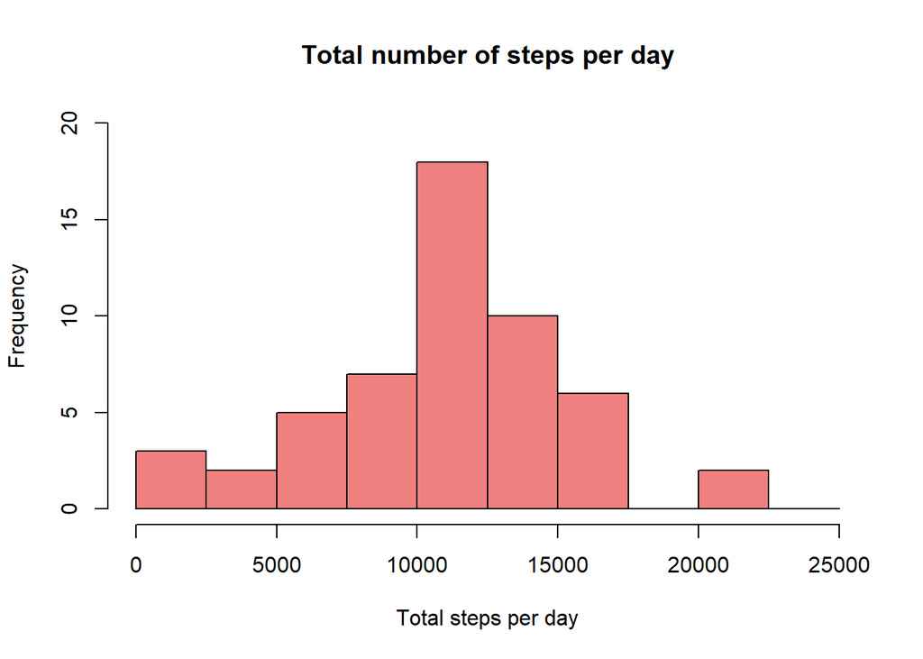

```r
summary_table <- aggregate(activity$steps ~ activity$date, FUN=sum, )
colnames(summary_table)<- c("Date", "Steps")

hist(summary_table$Steps,main = "Total number of steps per day",
     xlab="Total steps per day", col = "lightcoral",
     ylim = c(0,20), breaks = seq(0,25000, by=2500))
```

```r
mean(summary_table$Steps)
```

```
## [1] 10766.19
```

```r
median(summary_table$Steps)
```

```
## [1] 10765
```

## 3.What is the average daily activity pattern?

- Make a time series plot (i.e. type=“l”) of the 5-minute interval (x-axis) and the average number of steps taken, averaged across all days (y-axis)

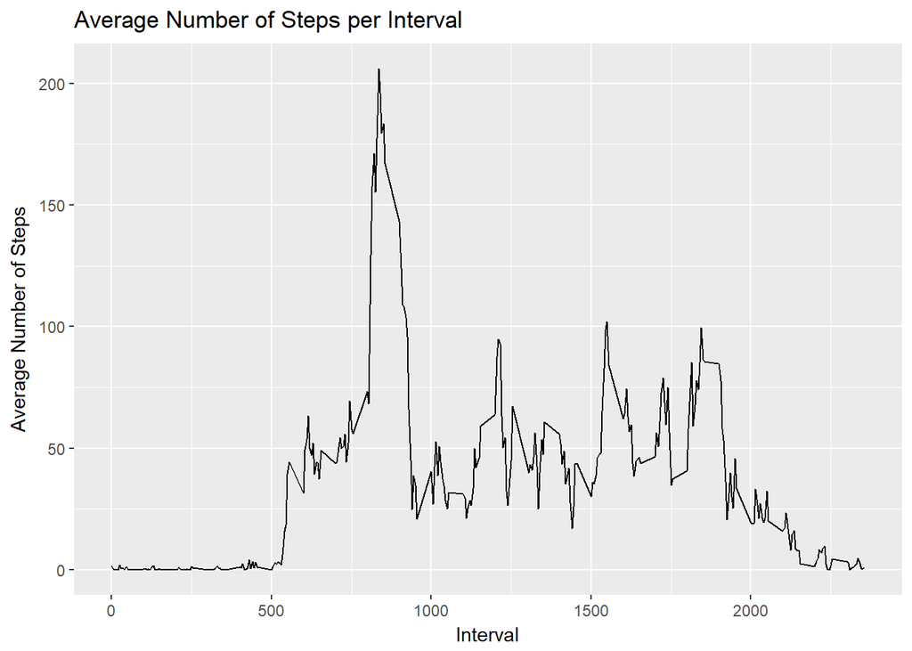

```r
clean <- activity[!is.na(activity$steps),]
p <- ggplot(ddply(clean, .(interval), summarize, Avg = mean(steps)), aes(x=interval, y=Avg),
            xlab = "Interval", ylab="Average Number of Steps")
p + geom_line()+xlab("Interval")+ylab("Average Number of Steps")+ggtitle("Average Number of Steps per Interval")
```

- Which 5-minute interval, on average across all the days in the dataset, contains the maximum number of steps?

```r
interval_table <- ddply(clean, .(interval), summarize, Avg = mean(steps))
maxSteps <- max(interval_table$Avg)
interval_table[interval_table$Avg==maxSteps,1]
```

```
## [1] 835
```

The 5-minute interval which had the maximum number of steps was the 835 interval.

## 4.Imputing missing values

- Calculate and report the total number of missing values in the dataset

```r
sum(is.na(activity$steps))
```

```
## [1] 2304
```

The total number of missing values is 2304.

- Devise a strategy for filling in all of the missing values in the dataset. The strategy does not need to be sophisticated. For example, you could use the mean/median for that day, or the mean for that 5-minute interval, etc.Create a new dataset that is equal to the original dataset but with the missing data filled in.

```r
average_table <- ddply(clean, .(interval, day), summarize, Avg = mean(steps))
nd<- activity[is.na(activity$steps),]
new_data_1<-merge(nd, average_table, by=c("interval", "day"))
new_data_2<- new_data_1[,c(6,4,1,2,5)]
colnames(new_data_2)<- c("steps", "date", "interval", "day", "DateTime")
mergeData <- rbind(clean, new_data_2)
summary_table_2 <- aggregate(mergeData$steps ~ mergeData$date, FUN=sum, )
colnames(summary_table_2)<- c("Date", "Steps")
```

- Make a histogram of the total number of steps taken each day and Calculate and report the mean and median total number of steps taken per day. Do these values differ from the estimates from the first part of the assignment? What is the impact of imputing missing data on the estimates of the total daily number of steps?

```r
mean(summary_table_2$Steps)
```

```
## [1] 10821.21
```

```r
median(summary_table_2$Steps)
```

```
## [1] 11015
```

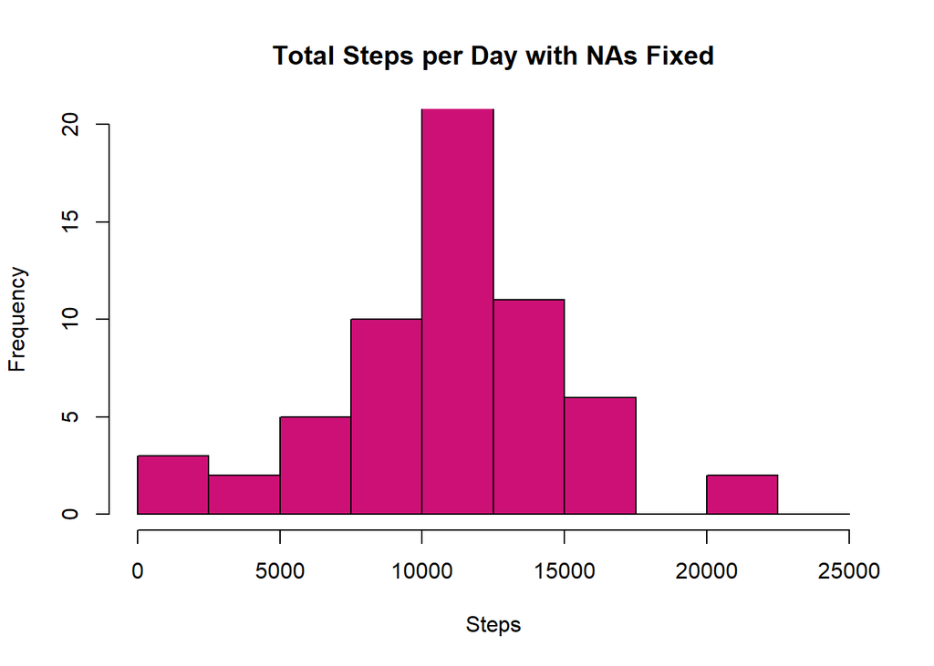

```r
hist(summary_table_2$Steps,xlab="Steps",
     main = "Total Steps per Day with NAs Fixed", col="deeppink3"
     ,ylim = c(0,20), breaks = seq(0,25000, by=2500))
```

Although the means have changed,it seems that the overall shape of the distribution has not changed.

## 4.Are there differences in activity patterns between weekdays and weekends?

- Create a new factor variable in the dataset with two levels – “weekday” and “weekend” indicating whether a given date is a weekday or weekend day.

```r
activity$date <- as.Date(strptime(activity$date, format="%Y-%m-%d"))
activity$datetype <- sapply(activity$date, function(x) {
  if (weekdays(x) == "Saturday" | weekdays(x) =="Sunday")
  {y <- "Weekend"} else
  {y <- "Weekday"}
  y
})
activity_by_date <- aggregate(steps~interval + datetype, activity, mean, na.rm = TRUE)
```

- Make a panel plot containing a time series plot of the 5-minute interval (x-axis) and the average number of steps taken, averaged across all weekday days or weekend days (y-axis). See the README file in the GitHub repository to see an example of what this plot should look like using simulated data.

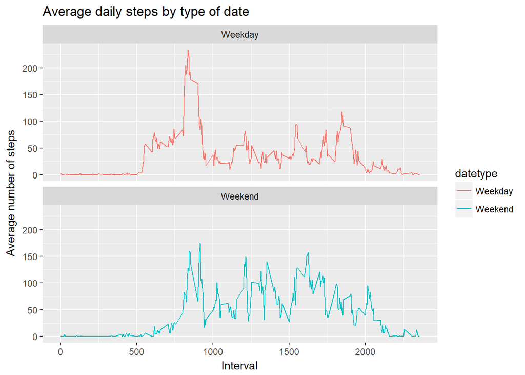

```r
plot<- ggplot(activity_by_date, aes(x = interval , y = steps, color = datetype)) +
  geom_line() +
  labs(title = "Average daily steps by type of date", x = "Interval",
       y = "Average number of steps") +
       facet_wrap(~datetype, ncol = 1, nrow=2)
print(plot)
```

Τhe step activity trends are different based on whether the day occurs on a weekend or not.